# Statistical Learning Final

Nicole Ely

Github: https://github.com/nely7539/StatisticalLearningSp21

## Introduction

Nuclear explosions have drastic effects on the people and world around them. From nuclear energy meltdowns, to testing and utilizing nuclear weapons, there have been over hundreds of recorded explosions. Looking at the data behind these explosions, we can begin to understand how these occur, whether the cause is war or accidental meltdown. We can also begin to understand how to prevent accidents, which would open up doors for utilizing nuclear power as a clean source of renewable energy.

## Importing Nuclear Explosions Data

```r
library(tidyverse)
library(ISLR)
library(caret)
library(MASS)
library(MLeval)

nuclear_explosions <- readr::read_csv("https://raw.githubusercontent.com/rfordatascience/tidytuesday/master/data/2019/2019-08-20/nuclear_explosions.csv")
```

```r
nuclear_explosions <-  na.omit(nuclear_explosions)
nuclear_explosions <-  nuclear_explosions
```

## Investigating and exploring data

```r
head(nuclear_explosions, 10)
```

| date_long | year | id_no | country | region | source | latitude | longitude | magnitude_body | magnitude_surface | depth | yield_lower | yield_upper | purpose | name | type |
| --- | --- | --- | --- | --- | --- | --- | --- | --- | --- | --- | --- | --- | --- | --- | --- |
| 19450716 | 1945 | 45001 | USA | ALAMOGORDO | DOE | 32.54 | -105.57 | 0 | 0 | -0.10 | 21 | 21 | WR | TRINITY | TOWER |
| 19450805 | 1945 | 45002 | USA | HIROSHIMA | DOE | 34.23 | 132.27 | 0 | 0 | -0.60 | 15 | 15 | COMBAT | LITTLEBOY | AIRDROP |
| 19450809 | 1945 | 45003 | USA | NAGASAKI | DOE | 32.45 | 129.52 | 0 | 0 | -0.60 | 21 | 21 | COMBAT | FATMAN | AIRDROP |
| 19460630 | 1946 | 46001 | USA | BIKINI | DOE | 11.35 | 165.20 | 0 | 0 | -0.20 | 21 | 21 | WE | ABLE | AIRDROP |
| 19460724 | 1946 | 46002 | USA | BIKINI | DOE | 11.35 | 165.20 | 0 | 0 | 0.03 | 21 | 21 | WE | BAKER | UW |
| 19480414 | 1948 | 48001 | USA | ENEWETAK | DOE | 11.30 | 162.15 | 0 | 0 | -0.08 | 37 | 37 | WR | X-RAY | TOWER |
| 19480430 | 1948 | 48002 | USA | ENEWETAK | DOE | 11.30 | 162.15 | 0 | 0 | -0.08 | 49 | 49 | WR | YOKE | TOWER |
| 19480514 | 1948 | 48003 | USA | ENEWETAK | DOE | 11.30 | 162.15 | 0 | 0 | -0.08 | 18 | 18 | WR | ZEBRA | TOWER |
| 19510127 | 1951 | 51001 | USA | NTS | DOE | 37.00 | -116.00 | 0 | 0 | -0.35 | 1 | 1 | WR | ABLE | AIRDROP |
| 19510128 | 1951 | 51002 | USA | NTS | DOE | 37.00 | -116.00 | 0 | 0 | -0.35 | 8 | 8 | WR | BAKER | AIRDROP |

### How many explosions have come from the USA? USSR?

```r
nuclear_explosions %>%
  filter(country == "USA") %>%
  nrow()
```

```
[1] 1029
```

```r
nuclear_explosions %>%
  filter(country == "USSR") %>%
  nrow()
```

```
[1] 100
```

```r
nuclear_explosions %>%
  filter(year == 1945)
```

| date_long | year | id_no | country | region | source | latitude | longitude | magnitude_body | magnitude_surface | depth | yield_lower | yield_upper | purpose | name | type |
| --- | --- | --- | --- | --- | --- | --- | --- | --- | --- | --- | --- | --- | --- | --- | --- |
| 19450716 | 1945 | 45001 | USA | ALAMOGORDO | DOE | 32.54 | -105.57 | 0 | 0 | -0.1 | 21 | 21 | WR | TRINITY | TOWER |
| 19450805 | 1945 | 45002 | USA | HIROSHIMA | DOE | 34.23 | 132.27 | 0 | 0 | -0.6 | 15 | 15 | COMBAT | LITTLEBOY | AIRDROP |
| 19450809 | 1945 | 45003 | USA | NAGASAKI | DOE | 32.45 | 129.52 | 0 | 0 | -0.6 | 21 | 21 | COMBAT | FATMAN | AIRDROP |

In 1945, the U.S. deployed nuclear bombs in response to an attack on Pearl Harbor. These can be seen when filtering the data when the year was 1945.

### What years had the highest number of explosions? Were these correlated to war/world issues?

```r
nuclear_explosions %>%
  group_by(year) %>%
  count() %>%
  arrange(desc(n))
```

| year | n |
| --- | --- |
| 1962 | 98 |
| 1958 | 82 |
| 1968 | 61 |
| 1966 | 55 |
| 1963 | 50 |
| 1964 | 49 |
| 1969 | 48 |
| 1970 | 48 |
| 1965 | 47 |
| 1967 | 46 |

[output cut: 37 more lines]

### What was occurring at this time? We can look at the data filtered by each year to view the countries of origin and target.

```r
nuclear_explosions %>%
  filter(year == 1962)
```

| date_long | year | id_no | country | region | source | latitude | longitude | magnitude_body | magnitude_surface | depth | yield_lower | yield_upper | purpose | name | type |
| --- | --- | --- | --- | --- | --- | --- | --- | --- | --- | --- | --- | --- | --- | --- | --- |
| 19620109 | 1962 | 62001 | USA | NTS | UGS | 37.000 | -116.200 | 0.0 | 0 | 0.00 | 5.10 | 5.10 | WR | STOAT | SHAFT |
| 19620118 | 1962 | 62002 | USA | NTS | UGS | 36.700 | -116.100 | 0.0 | 0 | 0.00 | 6.40 | 6.40 | WR | AGOUTI | SHAFT |
| 19620130 | 1962 | 62003 | USA | NTS | DOE | 37.000 | -116.000 | 0.0 | 0 | 0.00 | 0.00 | 20.00 | WR | DORMOUSE | SHAFT |
| 19620208 | 1962 | 62005 | USA | NTS | DOE | 37.000 | -116.000 | 4.3 | 0 | 0.20 | 3.07 | 3.07 | WR | STILLWATER | SHAFT |
| 19620209 | 1962 | 62006 | USA | NTS | DOE | 37.000 | -116.000 | 0.0 | 0 | 0.25 | 7.10 | 7.10 | WR | ARMADILLO | SHAFT |
| 19620215 | 1962 | 62007 | USA | NTS | DOE | 37.000 | -116.000 | 4.9 | 0 | 0.30 | 5.70 | 5.70 | WE | HARDHAT | SHAFT |
| 19620219 | 1962 | 62008 | USA | NTS | DOE | 37.000 | -116.000 | 3.9 | 0 | 0.15 | 1.90 | 1.90 | WR | CHINCHILLA | SHAFT |
| 19620219 | 1962 | 62009 | USA | NTS | DOE | 37.000 | -116.000 | 0.0 | 0 | 0.00 | 0.00 | 20.00 | WR | CODSAW | SHAFT |
| 19620223 | 1962 | 62010 | USA | NTS | DOE | 37.000 | -116.000 | 0.0 | 0 | 0.00 | 11.90 | 11.90 | WR | CIMARRON | SHAFT |
| 19620224 | 1962 | 62011 | USA | NTS | DOE | 37.000 | -116.000 | 0.0 | 0 | 0.00 | 0.00 | 20.00 | WR | PLATYPUS | SHAFT |

[output cut: 88 more lines]

This year shows numerous explosions originating in the USA, targeting the Nevada test site region. This shows that the US was testing nuclear weapons strenuously in 1962.

Further research into this topic explains the influx in testing, “The tests served various purposes such as: determining the impact of nuclear weapons on the physical environment and on man-made structures like military equipment; searching for possible peaceful uses of these weapons; testing the strength and effectiveness of new weapons; proof-testing existing weapons; and studying the effects of nuclear fallout”.

In this exploration, I expected world war 2-era years, for example 1945, to be rich in nuclear testing and weapon usage. This was very much not the case, and the findings show that there was a boom (no pun intended) in nuclear usage in the 1960s, which can be explained by the information above.

## Visualizing data

Magnitude (body) of explosions:

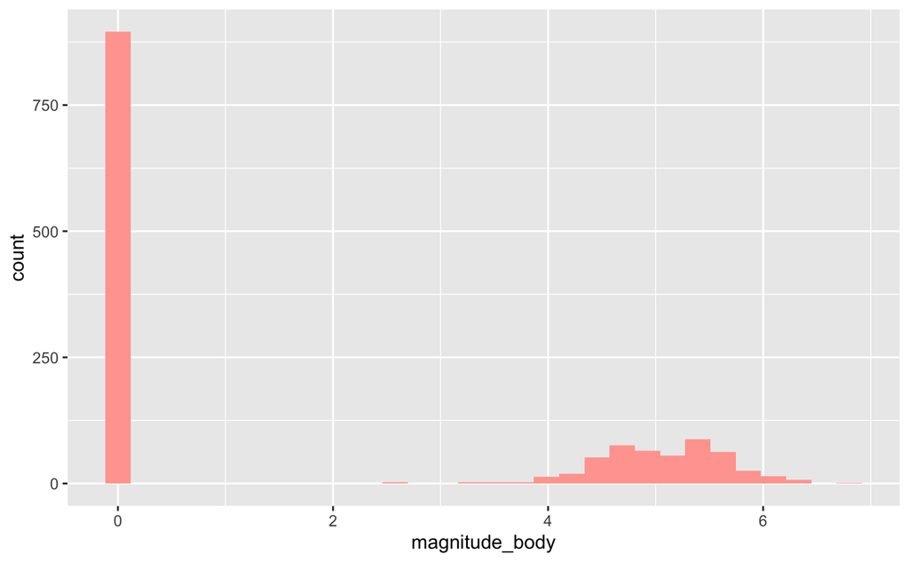

```r
nuclear_explosions %>%
  ggplot(aes(x = magnitude_body)) +
  geom_histogram(fill = "#FFA59F")
```

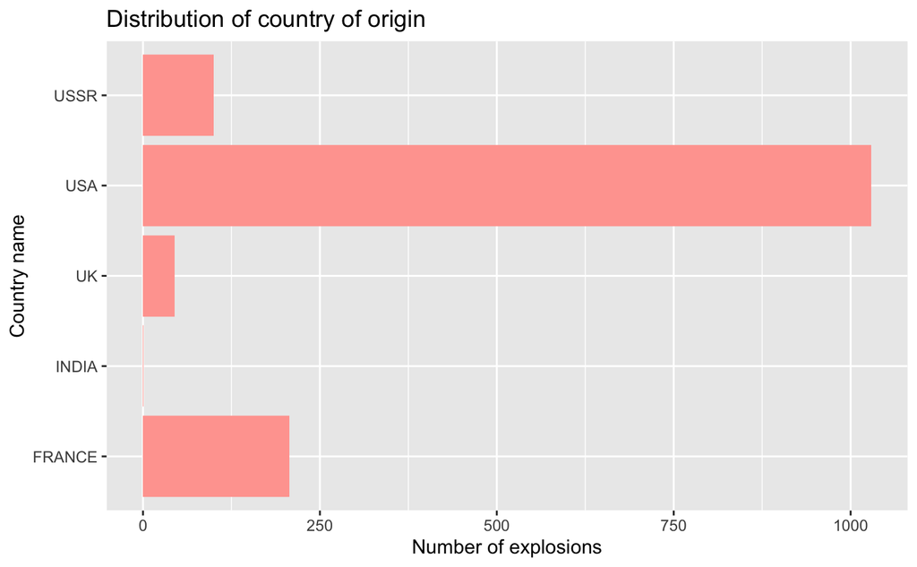

```r
nuclear_explosions %>%
  ggplot()+
  geom_bar(
    mapping = aes(
      x = country,
      ), fill = "#FFA59F") +
  labs(
    title = "Distribution of country of origin",
    x = "Country name",
    y = "Number of explosions") +
  coord_flip()
```

The U.S. is shown to be a powerhouse when it comes to nuclear explosions. I did not expect France to be the second highest, but it is interesting to see.

Year and magnitude:

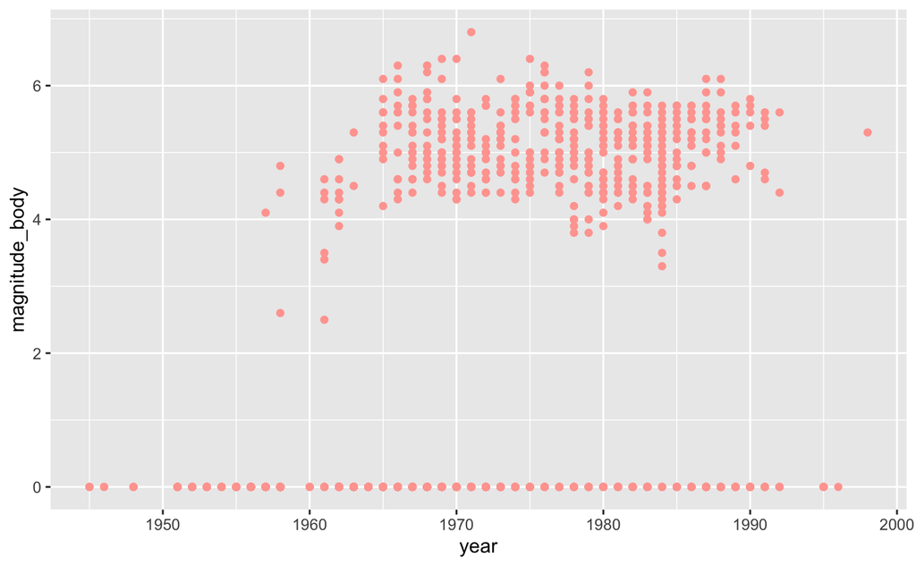

```r
nuclear_explosions %>%
  ggplot() +
  geom_point(aes(x = year, y = magnitude_body), color = "#FFA59F")
```

The magnitude of the explosions peaked somewhat in the 1970s. A large amount of points sit on or just above 0, which we can assume were testing.

## Modeling

Fit a linear model to the data, with magnitude as response, all others numerical attributes as predictors:

```r
lm.explosions <- lm(magnitude_body ~ year + latitude + longitude + depth + yield_upper + yield_lower, data = nuclear_explosions)
summary(lm.explosions)
```

```
Call:
lm(formula = magnitude_body ~ year + latitude + longitude + depth +
    yield_upper + yield_lower, data = nuclear_explosions)

Residuals:
    Min      1Q  Median      3Q     Max
-6.0131 -1.4642 -0.4352  1.5239  4.9707

Coefficients:
              Estimate Std. Error t value Pr(>|t|)
(Intercept) -2.190e+02  1.088e+01 -20.123  < 2e-16 ***
year         1.118e-01  5.521e-03  20.245  < 2e-16 ***
latitude     2.729e-02  2.485e-03  10.980  < 2e-16 ***
longitude    3.892e-03  7.127e-04   5.461 5.61e-08 ***
depth       -2.116e-03  4.201e-03  -0.504    0.615
yield_upper  1.182e-03  1.847e-04   6.399 2.15e-10 ***
yield_lower -1.190e-03  1.966e-04  -6.055 1.81e-09 ***
---
Signif. codes:  0 ‘***’ 0.001 ‘**’ 0.01 ‘*’ 0.05 ‘.’ 0.1 ‘ ’ 1

Residual standard error: 2.067 on 1375 degrees of freedom
Multiple R-squared:  0.2898,    Adjusted R-squared:  0.2867
F-statistic: 93.49 on 6 and 1375 DF,  p-value: < 2.2e-16
```

```r
lm.explosions2 <- lm(magnitude_body ~ year + latitude + longitude, data = nuclear_explosions)
summary(lm.explosions2)
```

```
Call:
lm(formula = magnitude_body ~ year + latitude + longitude, data = nuclear_explosions)

Residuals:
    Min      1Q  Median      3Q     Max
-4.8289 -1.5100 -0.4889  1.5531  5.0243

Coefficients:
              Estimate Std. Error t value Pr(>|t|)
(Intercept) -2.223e+02  1.087e+01 -20.457  < 2e-16 ***
year         1.135e-01  5.515e-03  20.577  < 2e-16 ***
latitude     2.690e-02  2.486e-03  10.820  < 2e-16 ***
longitude    3.751e-03  7.054e-04   5.318 1.22e-07 ***
---
Signif. codes:  0 ‘***’ 0.001 ‘**’ 0.01 ‘*’ 0.05 ‘.’ 0.1 ‘ ’ 1

Residual standard error: 2.095 on 1378 degrees of freedom
Multiple R-squared:  0.2685,    Adjusted R-squared:  0.2669
F-statistic: 168.6 on 3 and 1378 DF,  p-value: < 2.2e-16
```

```r
lm.year <- lm(magnitude_body ~ year, data = nuclear_explosions)
lm.lat <- lm(magnitude_body ~ latitude, data = nuclear_explosions)
lm.long <- lm(magnitude_body ~ longitude, data = nuclear_explosions)
```

```r
attach(nuclear_explosions)
```

```r
par(mfrow = c(1, 3))

#First plot
plot(year, magnitude_body)
abline(lm.year, col = "red", lwd = 3)
```

```r
#Second plot
plot(latitude, magnitude_body)
abline(lm.lat, col = "red", lwd = 3)
```

[figure not shown]

```r
#Third plot
plot(longitude, magnitude_body)
abline(lm.long, col = "red", lwd = 3)
```

Here, we can see that a linear model is not ideal for this data.

Other methods that can be used include polynomial regression:

```r
lm_fit <- train(magnitude_body ~ year + I(year^2) + I(year^3) + I(year^4),
                  data =nuclear_explosions, method = "lm")
```

```
prediction from a rank-deficient fit may be misleading
```

```r
summary(lm_fit)
```

```
Call:
lm(formula = .outcome ~ ., data = dat)

Residuals:
    Min      1Q  Median      3Q     Max
-3.4256 -1.6062  0.0002  1.7971  7.4715

Coefficients:
              Estimate Std. Error t value Pr(>|t|)
(Intercept) -9.322e+06  3.961e+07  -0.235    0.814
year         2.027e+04  8.039e+04   0.252    0.801
`I(year^2)` -1.645e+01  6.118e+01  -0.269    0.788
`I(year^3)`  5.915e-03  2.070e-02   0.286    0.775
`I(year^4)` -7.947e-07  2.625e-06  -0.303    0.762

Residual standard error: 2.112 on 1377 degrees of freedom
Multiple R-squared:  0.2573,    Adjusted R-squared:  0.2552
F-statistic: 119.3 on 4 and 1377 DF,  p-value: < 2.2e-16
```

```r
fit_1 <- train(magnitude_body ~ poly(year, degree = 1), data = nuclear_explosions, method = "lm")
fit_2 <- train(magnitude_body ~ poly(year, degree = 2), data = nuclear_explosions, method = "lm")
fit_3 <- train(magnitude_body ~ poly(year, degree = 3), data = nuclear_explosions, method = "lm")
fit_4 <- train(magnitude_body ~ poly(year, degree = 4), data = nuclear_explosions, method = "lm")
fit_5 <- train(magnitude_body ~ poly(year, degree = 5), data = nuclear_explosions, method = "lm")


#performing the ANOVA test
anova(
  fit_1$finalModel,
  fit_2$finalModel,
  fit_3$finalModel,
  fit_4$finalModel,
  fit_5$finalModel
)
```

```
Analysis of Variance Table

Model 1: .outcome ~ `poly(year, degree = 1)`
Model 2: .outcome ~ `poly(year, degree = 2)1` + `poly(year, degree = 2)2`
Model 3: .outcome ~ `poly(year, degree = 3)1` + `poly(year, degree = 3)2` +
    `poly(year, degree = 3)3`
Model 4: .outcome ~ `poly(year, degree = 4)1` + `poly(year, degree = 4)2` +
    `poly(year, degree = 4)3` + `poly(year, degree = 4)4`
Model 5: .outcome ~ `poly(year, degree = 5)1` + `poly(year, degree = 5)2` +
    `poly(year, degree = 5)3` + `poly(year, degree = 5)4` + `poly(year, degree = 5)5`
  Res.Df    RSS Df Sum of Sq       F    Pr(>F)
1   1380 6728.6
2   1379 6534.6  1    193.97 43.8593 5.046e-11 ***
3   1378 6143.8  1    390.86 88.3767 < 2.2e-16 ***
4   1377 6143.4  1      0.41  0.0925 0.7611150
5   1376 6085.6  1     57.81 13.0711 0.0003107 ***
---
Signif. codes:  0 ‘***’ 0.001 ‘**’ 0.01 ‘*’ 0.05 ‘.’ 0.1 ‘ ’ 1
```

We can then use step functions:

```r
table(cut(nuclear_explosions$year, 4))
```

```
(1.94e+03,1.96e+03] (1.96e+03,1.97e+03] (1.97e+03,1.98e+03]    (1.98e+03,2e+03]
                217                 552                 445                 168
```

```r
step_fit <- train(magnitude_body ~ cut(year, 4), data = nuclear_explosions,
                  method = 'glm')

summary(step_fit$finalModel)
```

```
Call:
NULL

Deviance Residuals:
    Min       1Q   Median       3Q      Max
-3.1627  -1.1766  -0.0733   1.9373   5.6234

Coefficients:
                                  Estimate Std. Error t value Pr(>|t|)
(Intercept)                        0.07327    0.14779   0.496     0.62
`cut(year, 4)(1.96e+03,1.97e+03]`  1.10336    0.17444   6.325 3.41e-10 ***
`cut(year, 4)(1.97e+03,1.98e+03]`  3.08942    0.18026  17.139  < 2e-16 ***
`cut(year, 4)(1.98e+03,2e+03]`     2.28863    0.22373  10.230  < 2e-16 ***
---
Signif. codes:  0 ‘***’ 0.001 ‘**’ 0.01 ‘*’ 0.05 ‘.’ 0.1 ‘ ’ 1

(Dispersion parameter for gaussian family taken to be 4.739674)

    Null deviance: 8271.9  on 1381  degrees of freedom
Residual deviance: 6531.3  on 1378  degrees of freedom
AIC: 6078.3

Number of Fisher Scoring iterations: 2
```

## References

Data set obtained from Tidy Tuesday by R for Data Science, at: https://github.com/rfordatascience/tidytuesday/tree/master/data/2019/2019-08-20

Information about nuclear history: https://www.atomicheritage.org/location/nevada-test-site